# GEO BON Toolbox

Models, tools, approaches and other means to support biodiversity conservation and ecosystem services assessments

Author

Juan Zuloaga & Andrew Gonzalez

Modified

August 16, 2024

## 1. Aim

This toolbox provides a compilation of **models, tools , approaches and other means** for measuring, monitoring and assessing multiple facets of **biodiversity and ecosystem services**.

It is aimed to help multiple partners in **planning and evaluating decisions** and policies in a region of interest.

**We used as an example the GEO BON-Parks Canada initiative** to compile and synthesize knowledge from an array of models, tools, scenarios, assessments and observatories that can be used and/or adapted to understand biodiversity change and ecosystem services assessments in the **Hudson James Bay Lowlands (HJBL)**.

We truly believe that this compilation can be **extended and used in other initiatives**. To that end, we are planning to add some interactive tools to facilitte partners to collaborate and expand any section of this Toolbox.

This is a work in progress, so you will find this message: **This section is under construction!**

## 2. The conceptual framework

We used the [IPBES (2016)](https://www.ipbes.net/document-library-catalogue/methodological-assessment-report-scenarios-and-models-biodiversity-and) conceptual framework that provides guidance for the use of scenarios, models and tools for implementing regional and global assessments, designing policy and management strategies and addressing gaps in data and knowledge relevant to biodiversity and ecosystem services, among others.

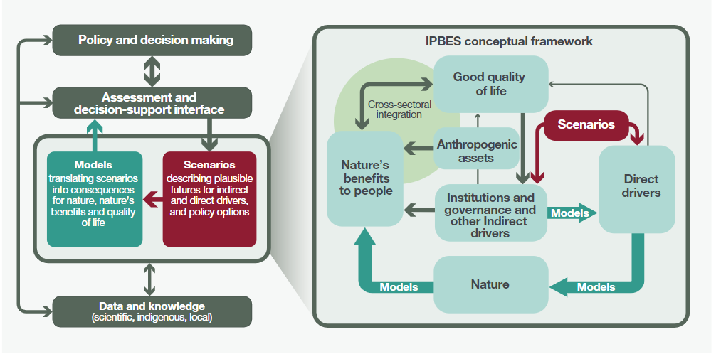

The **figure above** depicts two main elements of the [IPBES (2016)](https://www.ipbes.net/document-library-catalogue/methodological-assessment-report-scenarios-and-models-biodiversity-and) conceptual framework: first (left) the role of models and scenarios in linking data and knowledge to policy and decisions making, and secondly (right) a simplified conceptualization of the relationships among components of nature and society. It shows how models and scenarios can mediate the flows of knowledge that guide action in different sectors of the economy for the conservation and sustainable use of biodiversity and ecosystem services and human well-being. Similar conceptualizations in other knowledge systems include ‘living in harmony with nature’ and ‘Mother Earth’, among others. The concepts of ‘nature’, ‘nature’s benefits to people’ and ‘good quality of life’ are inclusive of all these worldviews.

**IPBES 2016 framework: Description of components (models, tools, scenarios, observatories, assessment).**

**Scenarios**

“Scenarios capture different policy options being considered by decision makers, which are then translated by models into consequences for nature, nature’s benefits to people and quality of life”. ([IPBES 2016](https://www.ipbes.net/document-library-catalogue/methodological-assessment-report-scenarios-and-models-biodiversity-and)). For instance, intervention scenarios evaluate alternative policy or management, contributing to policy design and implementation.

**Models**

Models are used to understand how ecological processes interact and predict how biodiversity, ecosystem services and human wellbeing might change. Models formalize relationships among the elements of complex social-ecological systems. Models are qualitative or quantitative descriptions of key components of a system and relationships between those components. Most models (and most tools) have a very specific focus: the more quantitative and exact they are, the more focused the models/tools are on a specific section of the social-ecological system. “Models can provide a useful means of translating alternative scenarios of drivers or policy interventions into projected consequences for nature and nature’s benefits to people” ([IPBES 2016](https://www.ipbes.net/document-library-catalogue/methodological-assessment-report-scenarios-and-models-biodiversity-and)). Species Distribution Models (SDMs) is an example of a model that uses spatial environmental data to make inferences about species’ range limits and habitat suitability. Structural equation models can be used to understand the relationships between biodiversity and wellbeing.

**Tools**

A set of workflows and associated algorithms representing models and approaches that perform specific tasks and provide users with quantitative or qualitative outputs, usually spatially and temporally explicit. They work well when they are well maintained and updated regularly for an active user community. [InVEST](https://naturalcapitalproject.stanford.edu/software/invest) and [Bon in A Box](https://boninabox.geobon.org/) are examples of tools that can offer and streamline multiple models.

**Weaving multiple-knowledge systems**

Weaving multiple knowledge systems “refers to a process through which multiple types of knowledge are equitably brought together to enable the reciprocal exchange of understanding for mutual learning and application” ([Henri et al. 2021](https://besjournals.onlinelibrary.wiley.com/doi/full/10.1002/2688-8319.12057#:~:text='Weaving%20knowledge%20systems'%20refers%20to,et%20al.%2C%202017)).

**Observatories**

Observatories are multi-partner and multi-actor organizations that gather, curate, and share data and knowledge about the changing state of ecological components of a geographic region. Observatories combine observation technologies to produce standardized variables and indicators of change that can guide investments in conservation action and resource management. [GEO BON](https://geobon.org/) and the [CreeGeo Hub](https://www.mushkegowuk.ca/informationservices) are examples of global and community lead observatories, respectively.

**Assessment**

Multiple partners working together proposed to explore plausible future scenarios to be tested with data and models. The assessment evaluates vulnerabilities and risks for a specific case, such as the HJBL, under different scenarios.

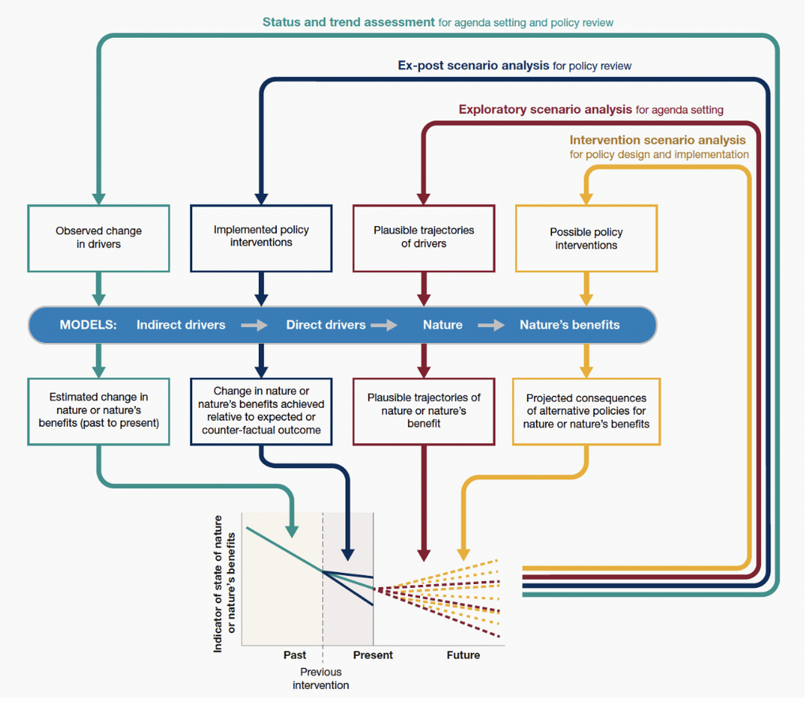

## 3. What is in the Toolbox?

We follow the ([IPBES 2016](https://www.ipbes.net/document-library-catalogue/methodological-assessment-report-scenarios-and-models-biodiversity-and)) framework to structure all these sections in this toolbox. Integrating and operationalizing multiple sections from the toolbox will allow partners working and living in a region evaluate alternative intervention policies and/or management strategies under multiple scenarios to provide relevant and strategic information for decision-making.

Each section contains a description, including case studies and useful links for further readings. We also provide on each section important findings and some guidance to operationaliza furhter actions. These findings and guidance come from two sources: a workshop held in Montreal in October 2023 whith multiple partners working and living in the HJBL and a literature review.

We acknowledge that there may be models, tools, approaches and other means out there that escaped this review, while noting that there are some biophysical components and ecosystem services that were more explored and covered than others. So, further efforts should focus on tackling these gaps and updating models and tools when possible.

**Planning**

Before you start digging into models, tools and other means, take your time to ask yourself **what do you want to accomplish and what do you need for that**.

We are working to provide an interactive tool for planning your initiative. In the **example below** partners will have the opportunity to design their projects and have a road map to track planning and implementation. **This section is under construction!**

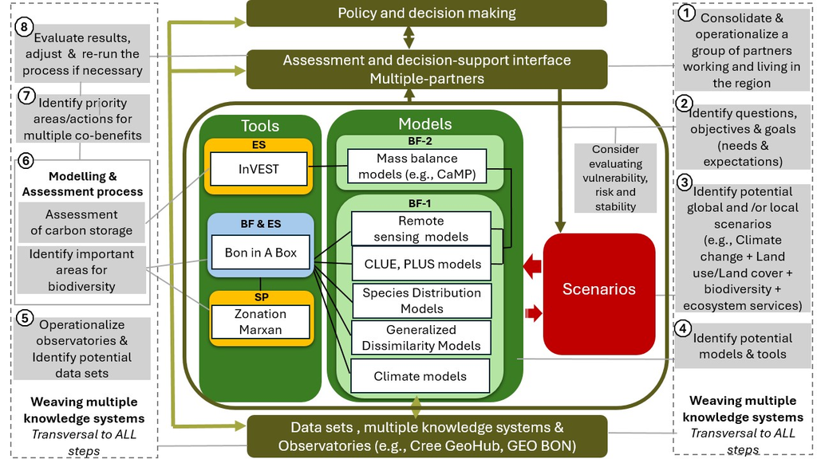

**An example of planning a project** using the [IPBES (2016)](https://www.ipbes.net/document-library-catalogue/methodological-assessment-report-scenarios-and-models-biodiversity-and) framework (note: GEO BON is planning to develop a tool where partners can select potential models, tools, scenarios, etc., according to their needs.

**Weaving**

**Weaving Multiple Knowledge Systems:** Here we provide some fundamental ideas and approaches to help partners weaving multiple knowledge systems in this endeavor of protecting biodiversity and managing ecosystems services.

**Observatories:** It includes global and regional observatories that can support multiple partners in the region. We encourage partners to identify potential local initiatives that can serve as a local hubs partnering with national and global observatories.

**Scenarios**

We provide a review of two main Scenarios approaches (top-down and bottom-up) that can help partners to describe and assess narratives of possible futures.

**Models & Tools**

This is a compilation of models and tools to measure or assess some facet of biodiversity, physical features and ecosystem services. Again, it is a growing list and we expect contributions from the GEO BON community.

We included in this section a preliminary list of global and regional data sets that can support biodiversity and ecosystem services modeling and assessment. This is not an exhaustive list of data sets and we expect it will grow with support of the GEO BON community. We also expect national and local partners to contribute and help growing this section. Knowing what type of data and where these data sets are available will facilitate the whole process.

**Biophysical features (BFs)**

- BF-1: Biodiversity.
- BF-2: Quantifying carbon storage.
- BF-3: Permafrost.
- BF-4: Rivers & Basins.
- BF-5: Wetlands.
- BF-6: Lakes.
- BF-7: Water
- BF-8: Fire regimes

**Ecosystem services (ESs)**

- ES-1: Ecosystem services.

**Spatial prioritization (SP)**

- SP: Spatial prioritization

**Approaches**

Biodiversity conservation and ecosystem services management requires the implementation of multiple approaches to achieve desired goals and targets. However, the integration of multiple models and multiple components from social, economic and biophysical system is a necessity to understand the complexity, interactions and feed backs.

These approaches (see Approaches section) span from species-specific and area-based approaches to multi-objective and scenario assessments.

**The region**

We describe the main biophysical, socioeconomic and cultural systems in **the Hudson James Bay Lowlands (HJBL)**.

## 4. Contributors

**Workshop list of participants & contributors to the document**

**GEO BON - Parks Canada workshop Hudson-James Bay Lowlands (Oct 16-17, 2023, in Montreal)**

Contributors to the main document in **BOLD**

[output not shown]